# final_R_reference

2022-11-29

# R Reference Guide

## Loading Data and Packages

### How to install packages:

# load a package not pre-installed into R:

install.packages(“package name”)

require(package name)

# Use library() to see what R packages are installed

#### Palmer Penguins Example

install.packages(“palmerpenguins”)

require (palmerpenguins)

#library() also works:

library(palmerpenguins)

### How to load data:

require(here)

#here() finds files within the directory the R project is located

vec_name = read.csv( here(“data”, “data_name.csv”)

#### Ginkgo Data Example

require(here)

dat_ginkgo = read.csv( here(“data”, “ginkgo_data_2021.csv”) )

# use head to see vector data

head(dat_ginkgo)

## Data Structures

### Function c()

The function c() combines arguments into a vector (a 1-dimensional data structure consisting of 1 or more elements).

All of the elements must be of the same type. I can’t combine character and numeric types in the same call to c()

Here’s two examples using numeric and character data types:

```r
# Create a vector of numbers:

num_vec = c(1, 4, 8, 9, 13)

# Create a vector of characters:

char_vec = c("a", "fish", "data is cool")

#I can show the contents of a vector by typing the name of the vector, or using the print() function.

# Typing the name of the vector into the console prints the contents

num_vec
```

```
## [1]  1  4  8  9 13
```

```r
# The print() function accomplishes the same task:

print(char_vec)
```

```
## [1] "a"            "fish"         "data is cool"
```

### Function length()

Get or set the length of vectors (including lists) and factors, and of any other R object for which a method has been defined. For vectors (including lists) and factors the length is the number of elements.

Example 1:

```r
# this prints "5"

length(num_vec)
```

```
## [1] 5
```

Example 2:

```r
n = 12345

vec_1 = sample(12, n, replace = TRUE)

head(vec_1)
```

```
## [1]  5 11 12  9  3  5
```

### Function matrix()

A matrix is a collection of elements of the same data type (numeric, character, or logical) arranged into a fixed number of rows and columns.

```r
#Example:

my_vec = 1:6

my_vec
```

```
## [1] 1 2 3 4 5 6
```

```r
mat_1 = matrix(my_vec, nrow = 3)

mat_1
```

```
##      [,1] [,2]
## [1,]    1    4
## [2,]    2    5
## [3,]    3    6
```

### Function data.frame()

collections of variables which share many of the properties of matrices and of lists, used as the fundamental data structure by most of R’s modeling software

```r
# call data into a data.frame()
require(here)
dat_ginkgo = read.csv( here("data", "ginkgo_data_2021.csv") )

#dat_ginkgo is a data frame
```

### dat_ginkgo example

```r
#returns number of rows in the dataset

nrow(dat_ginkgo)
```

```
## [1] 756
```

```r
#returns number of columns in the dataset

ncol(dat_ginkgo)
```

```
## [1] 6
```

```r
#returns all dimensions of the data set (both nrow & ncol)
dim(dat_ginkgo)
```

```
## [1] 756   6
```

## Subsetting

### Example 1

## Use subset() to select & exclude variables or observations

#Here subset selects only ginkgo trees that had seeds present at the site

```r
ginkgo_subset = subset(dat_ginkgo, seeds_present == "TRUE", na.rm = FALSE)
```

### Example 2

```r
require(palmerpenguins)
adelie = subset(penguins, species == "adelie")

#You can also use =! to exclude a species
```

## Numerical Data Exploration

```r
#summary() will show the 5 # summaries for all columns in the data
summary(dat_ginkgo)
```

```
##     site_id      seeds_present     max_width        max_depth
##  Min.   : 1896   Mode :logical   Min.   : 16.00   Min.   : 19.00
##  1st Qu.: 3703   FALSE:636       1st Qu.: 63.00   1st Qu.: 43.00
##  Median : 6066   TRUE :120       Median : 74.00   Median : 51.00
##  Mean   : 6079                   Mean   : 74.34   Mean   : 58.51
##  3rd Qu.: 7206                   3rd Qu.: 85.00   3rd Qu.: 66.00
##  Max.   :12982                   Max.   :130.00   Max.   :145.00
##
##   notch_depth    petiole_length
##  Min.   : 0.00   Min.   :  8.00
##  1st Qu.: 0.00   1st Qu.: 34.00
##  Median : 0.00   Median : 47.00
##  Mean   : 2.99   Mean   : 48.25
##  3rd Qu.: 4.00   3rd Qu.: 60.00
##  Max.   :49.00   Max.   :113.00
##                  NA's   :4
```

```r
#use $ to call to a specific subset of data

mean(dat_ginkgo$max_depth)
```

```
## [1] 58.51455
```

```r
sd(dat_ginkgo$max_depth)
```

```
## [1] 23.46108
```

## Graphical Data Exploration

### Example 1

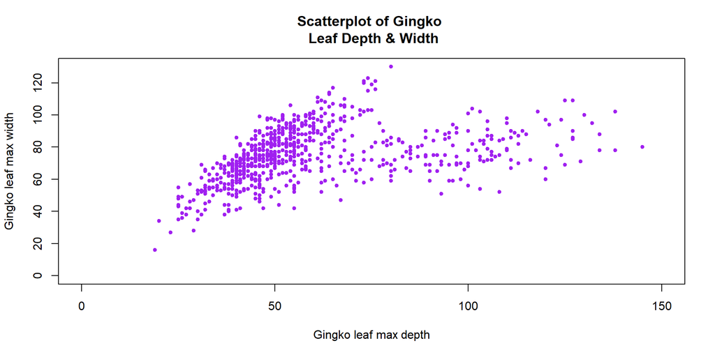

```r
plot(dat_ginkgo$max_depth, dat_ginkgo$max_width,

main = "Scatterplot of Gingko \n Leaf Depth & Width",

xlab = "Gingko leaf max depth",

ylab = "Gingko leaf max width",

xlim = c(0, 150), ylim = c(0, 130),

col = "purple",

pch = 20,

cex = 1 )
```

### Example 2

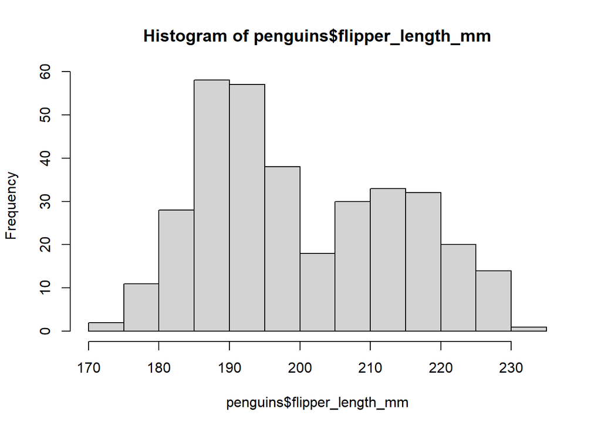

```r
hist(penguins$flipper_length_mm, breaks = 10)
```

### Example 4

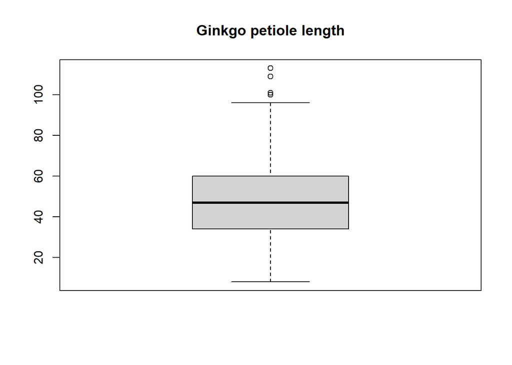

```r
boxplot(dat_ginkgo$petiole_length, main = "Ginkgo petiole length" )
```

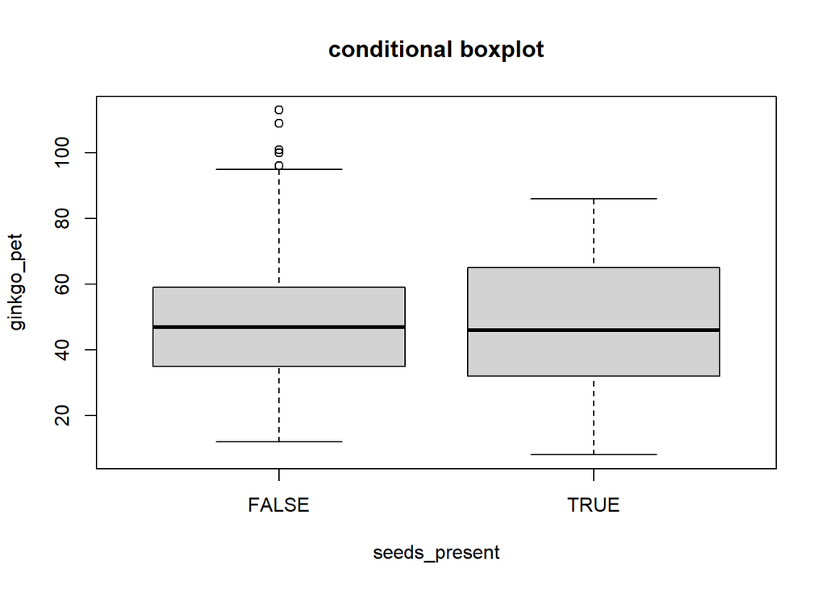

```r
ginkgo_pet = dat_ginkgo$petiole_length

boxplot( formula = ginkgo_pet ~ seeds_present, data = dat_ginkgo, main = "conditional boxplot")
```

### Example 5

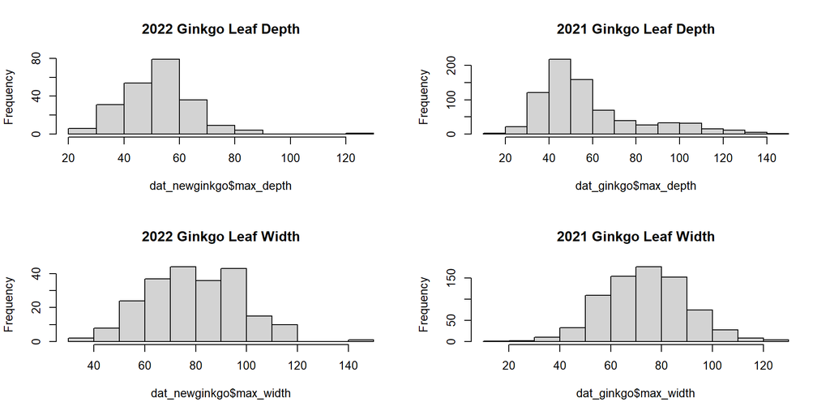

```r
dat_ginkgo = read.csv( here("data",
"ginkgo_data_2021.csv"))

dat_newginkgo = read.csv( here("data",
"ginkgo_data_2022.csv"))

par(mfrow = c(2,2))

hist(dat_newginkgo$max_depth, main = "2022 Ginkgo Leaf Depth")

hist(dat_ginkgo$max_depth, main = "2021 Ginkgo Leaf Depth")

hist(dat_newginkgo$max_width, main = "2022 Ginkgo Leaf Width")

hist(dat_ginkgo$max_width, main = "2021 Ginkgo Leaf Width")
```

## Distribution Functions

### Key terms

The two parameters of a binomial distribution: n, number of trials, and P, probability of success for each trial

Combinations- order doesn’t matter; permutation: order matters

dnorm gives the density, pnorm gives the distribution function, qnorm gives the quantile function, and rnorm generates random deviates.

### dnorm()

uses a standard normal with mean = 0 and sd = 1

Example

```r
dnorm(.7, 0, 1)
```

```
## [1] 0.3122539
```

### pnorm()

This is for calculating a cumulative distribution

Examples

The probability of observing a value of less than 1.2 from a normally-distributed population with mean = 2 and standard deviation = 2?

```r
pnorm(1.2, mean = 2, sd = 2)
```

```
## [1] 0.3445783
```

The probability of observing a value of greater than 1.2 from a normally-distributed population with mean = 2 and standard deviation = 2?

```r
# could also use lower.tail = FALSE in code.

1-pnorm(1.2, mean = 2, sd = 2)
```

```
## [1] 0.6554217
```

### qnorm()

Finds value of a boundary given an area

Example

```r
qnorm(0.40,mean=50,sd=2)
```

```
## [1] 49.49331
```

### dbinom()

Examples The probability of observing a count of exactly 3 successes in a binomial distribution with parameters n = 4 and p = 0.75? dbinom(x = 3, size = 4, prob = 0.75, log = FALSE)

```r
#The probability of observing birds in exactly four of six patches.
dbinom(x=4, size = 6, prob = 2/3, log = FALSE)
```

```
## [1] 0.3292181
```

### pbinom()

Example

The probability of observing a count of 3 successes or fewer in a binomial distribution with parameters n = 4 and p = 0.75?

```r
pbinom(q = 3, size = 4, prob = 0.75, lower.tail = TRUE, log.p = FALSE)
```

```
## [1] 0.6835937
```

### qbinom()

Returns the inverse cumulative density function (cdf) qbinom(q, size, prob) x: a vector of numbers. size: the number of trials. prob: the probability of success of each trial.

Example

```r
qbinom(.26, size=40, prob=.4)
```

```
## [1] 14
```